# EGI Simulations

A.Nuur

2/16/2022

# EGI Assginment 1:

In this code, you can find all the code that I did (with the help of Max’s, Mathieu’s, and Google’s help). I covered three simulations. The **second simulation** is not complete for Mathieu’s…unless Max forgot to push it into Github.

I just realised that this is the first round, smh! Anyways, I haven’t answered all the thoertical parts of sim3 yet. For sim4, I could not do it since I haven’t properly studied it yet.

packages

```r
library(ggplot2); library(tidyverse); library(readxl)
```

Parameters

```r
#Parameter
s<- 0.25
n <- 0.03
alpha <- 0.33
dep_rate <- 0.04
g <- 0.02
```

Initial values

```r
#Initial values
L0 <- 45.00
K0 <- 1075795.25
k0 <- K0/L0
A0 <- 10862.74
Y0 <- K0^(alpha) * (A0*L0)^(1-alpha)
year <- seq(2020, 2100, 1)
period <- 1:81
```

## Sim1

### Step1 calculate population and technology level

```r
#Population, L
L <- rep(NA, 81)
A <- rep(NA, 81)
L[1]<- L0
A[1]<- A0
for(i in 2:81){
  L[i]<- L[i-1]*exp(n)
  A[i]<- A[i-1]*exp(g)
}
```

## Step2 calculate physical capital, physical cpaital per worker, then gdpPercap

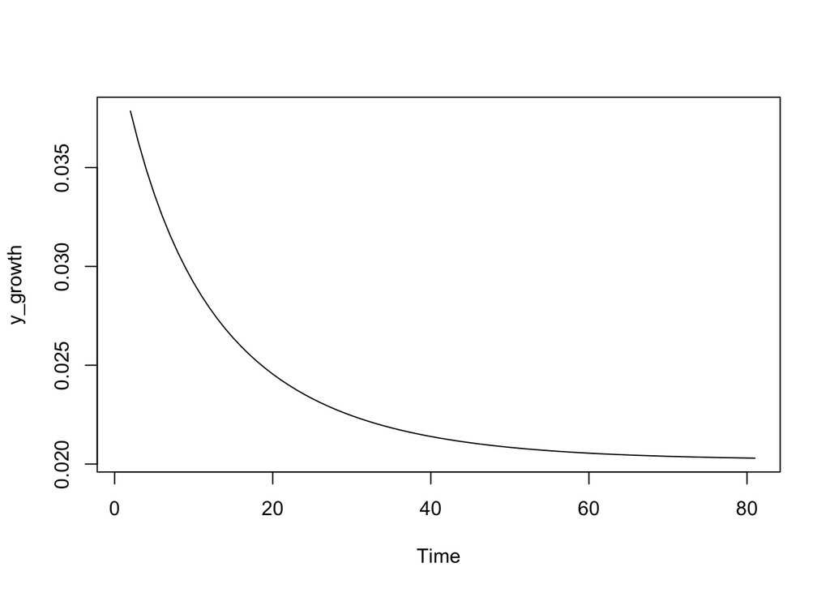

```r
K <- rep(NA, 81)
k <- rep(NA, 81)
Y <- rep(NA, 81)
y<- rep(NA, 81)
y_growth <- rep(NA, 81)
K[1]<- K0
k[1]<- k0
Y[1]<- Y0
y[1]<- (Y0/L0)
y_growth[1 ]<- (y[2]- y[1]) / y[1]

for(i in 2:81){
  K[i]<- (1-dep_rate)*K[i-1] + s*Y[i-1]
  Y[i] <- K[i]^(alpha) * (A[i]*L[i])^(1-alpha)
  k[i] <- (K[i]/L[i])
  y[i] <- (Y[i])/ L[i]
  y_growth[i] <- (y[i] -y[i-1]) / y[i-1]
}
plot.ts(y_growth)
```

```r
#Period is fishy
k <- K/L
```

###dataframe

```r
sim_1 <- data.frame(Year= year, Period= period, tech= round(A,3), Labor= round(L,3),Kapital= round(K,3), small_k = round(k,39), GDP= round(Y,3), gdpPercap= y,y_hat = round(y_growth,3))
```

1. Present a line chart of the growth rate of GDP per capita, computed in the previous step, as a function of time for the 2020-2100 period.

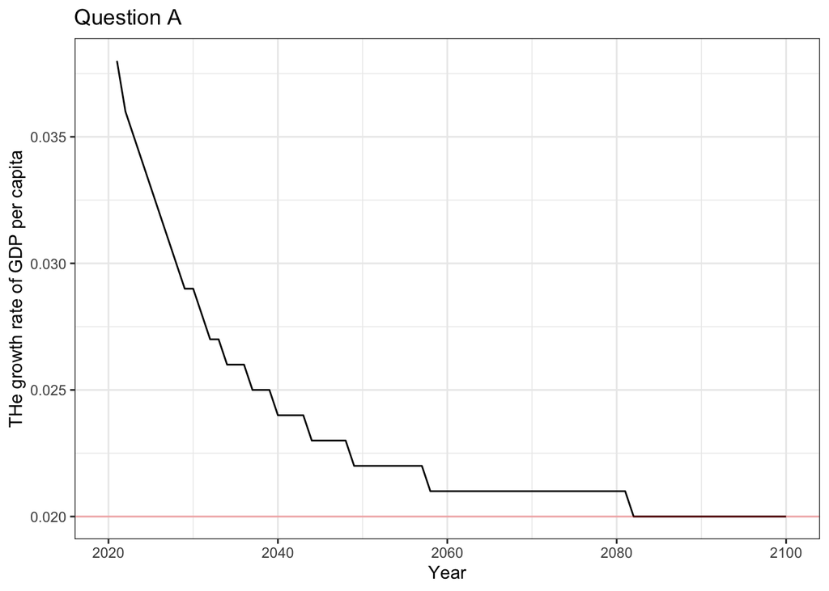

```r
ggplot()+
  geom_line(sim_1, mapping= aes(x= Year,y_hat ))+
 geom_hline(yintercept = 0.020, color= "red", alpha= 0.3)+

  theme_bw()+
  labs(y= "THe growth rate of GDP per capita", title = "Question A")
```

2. Based on the figure, is GDP per capita in 2020 below or above its steady state level. Justify your answer by explicitly referring to how the growth rate GDP per capita evolves over time. Approximately, in which year does the economy reach the steady state?

##Sim2

###Step1: The ex-ante: the forecast

####Calculating forecasted A

```r
theta <- 0.05
prob_sim2 <- 0.05
#Population, L
L_sim2 <- L0*exp(n*(year-2020))
#Forecasted Tech
A_sim2_ex<-  A0*exp(g*(year-2020))* (1- (theta* prob_sim2))^(year - 2020)


# The rest
K_sim2_ex <- rep(NA, 81)
k_sim2_ex <- rep(NA, 81)
Y_sim2_ex <- rep(NA, 81)
y_sim2_ex<- rep(NA, 81)
y_growth_sim2_ex <- rep(NA, 81)
K_sim2_ex[1]<- K0
k_sim2_ex[1]<- k0
Y_sim2_ex[1]<- Y0
y_sim2_ex[1]<- (Y0/L0)
y_growth_sim2_ex[1 ]<- (y_sim2_ex[2]- y_sim2_ex[1]) / y_sim2_ex[1]

for(i in 2:81){
  K_sim2_ex[i]<- (1-dep_rate)*K_sim2_ex[i-1] + s*Y_sim2_ex[i-1]
  Y_sim2_ex[i] <- K_sim2_ex[i]^(alpha) * (A_sim2_ex[i]*L_sim2[i])^(1-alpha)
  k_sim2_ex[i] <- (K_sim2_ex[i]/L_sim2[i])
  y_sim2_ex[i] <- (Y_sim2_ex[i])/ L_sim2[i]
  y_growth_sim2_ex[i] <- (y_sim2_ex[i] -y_sim2_ex[i-1]) / y_sim2_ex[i-1]
}
#The dataframe
sim2_ex <- data.frame(Year= year, Period= period, theta= theta, prob= prob_sim2, tech_ex= A_sim2_ex, Labor= L_sim2,Kapital_ex= K_sim2_ex, small_k_ex = k_sim2_ex, GDP_ex= Y_sim2_ex,gdpPercap_ex= y_sim2_ex, y_hat_ex = y_growth_sim2_ex)
```

###Step2: ex-post. Random realisations It’s a bern distribution

```r
library(Rlab)
#I need to cacluate the probability of each year, then calculate Expected tech level
#paramter of negative productivity shock

#w can only be achieved by simulation
w_sim2 <- rbinom(length(2020:2100),1, prob= 0.05)
theta <- 0.05
```

Pop, A

```r
#Population, L
L_sim2
```

```
##  [1]  45.00000  46.37045  47.78264  49.23784  50.73736  52.28254  53.87478
##  [8]  55.51551  57.20621  58.94840  60.74365  62.59357  64.49982  66.46414
## [15]  68.48827  70.57405  72.72335  74.93810  77.22031  79.57202  81.99535
## [22]  84.49248  87.06566  89.71720  92.44949  95.26500  98.16625 101.15586
## [29] 104.23651 107.41099 110.68214 114.05291 117.52634 121.10555 124.79376
## [36] 128.59430 132.51058 136.54613 140.70458 144.98967 149.40526 153.95533
## [43] 158.64397 163.47540 168.45396 173.58415 178.87057 184.31799 189.93131
## [50] 195.71558 201.67601 207.81796 214.14696 220.66870 227.38906 234.31409
## [57] 241.45002 248.80327 256.38045 264.18840 272.23414 280.52490 289.06815
## [64] 297.87159 306.94313 316.29094 325.92343 335.84928 346.07741 356.61704
## [71] 367.47765 378.66901 390.20119 402.08459 414.32989 426.94811 439.95062
## [78] 453.34911 467.15565 481.38265 496.04294
```

```r
A_sim2_post <- rep(NA, 81)
A_sim2_post[1]<- A0
for(i in 2:81){
  A_sim2_post[i]<- A_sim2_post[i-1]*exp(g)*(1-((w_sim2[i])*theta))
 }


# The rest
K_sim2_post <- rep(NA, 81)
k_sim2_post <- rep(NA, 81)
Y_sim2_post <- rep(NA, 81)
y_sim2_post<- rep(NA, 81)
y_growth_sim2_post <- rep(NA, 81)
K_sim2_post[1]<- K0
k_sim2_post[1]<- k0
Y_sim2_post[1]<- Y0
y_sim2_post[1]<- (Y0/L0)
y_growth_sim2_post[1 ]<- (y_sim2_post[2]- y_sim2_post[1]) / y_sim2_post[1]

for(i in 2:81){
  K_sim2_post[i]<- (1-dep_rate)*K_sim2_post[i-1] + s*Y_sim2_post[i-1]
  Y_sim2_post[i] <- K_sim2_post[i]^(alpha) * (A_sim2_post[i]*L_sim2[i])^(1-alpha)
  k_sim2_post[i] <- (K_sim2_post[i]/L_sim2[i])
  y_sim2_post[i] <- (Y_sim2_post[i])/ L_sim2[i]
  y_growth_sim2_post[i] <- (y_sim2_post[i] -y_sim2_post[i-1]) / y_sim2_post[i-1]
}
```

####The dataframe

```r
sim2_post <- data.frame(Year= year, Period= period,  W=w_sim2,tech_post= A_sim2_post, Labor= L_sim2,Kapital_post= K_sim2_post, small_k_post = k_sim2_post, GDP_post= Y_sim2_post,gdpPercap_post= y_sim2_post, y_hat_post = y_growth_sim2_post)
```

4. ] List the years for which there is an extreme weather event according to your simulation.

```r
sim2_post[which(sim2_post$y_hat <0), "Year"]
```

```
## [1] 2040 2060 2081
```

For clairty: To see the gdpPcap growth rate over time.

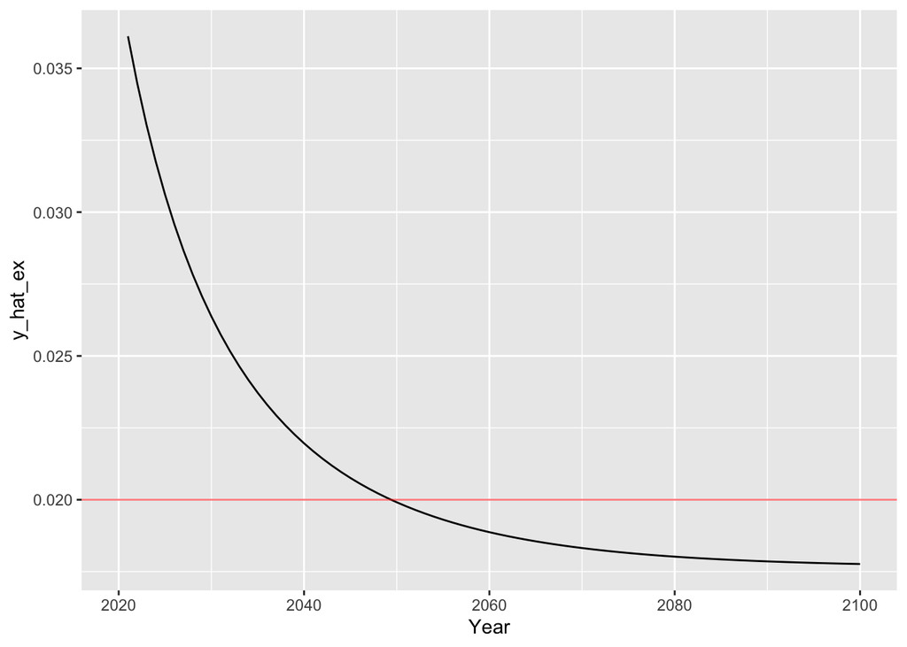

```r
ggplot(sim2_ex, mapping= aes(Year,y_hat_ex ))+
  geom_line()+
  geom_hline(yintercept = 0.020, color= "red", alpha= 0.5)
```

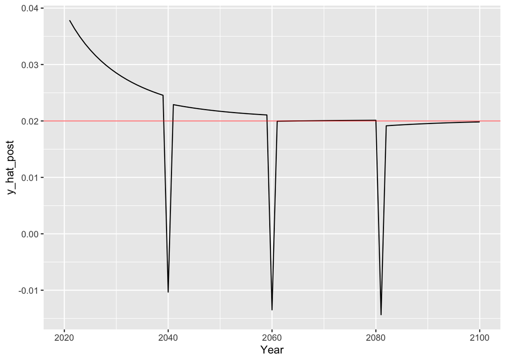

```r
ggplot(sim2_post, mapping= aes(Year,y_hat_post ))+
  geom_line()+
  geom_hline(yintercept = 0.020, color= "red", alpha= 0.5)
```

## Third simulation

creating a seq of the probs

```r
#For ex-ante
prob_sim3 <- rep(NA, 81)
prob_sim3[1:31] <- seq( 0.050,0.20, by=0.005)
prob_sim3[32:81] <- 0.20

theta_sim3 <- 0.05
```

###Step1: Ex-ante ####Calculating forecasted A

```r
theta <- 0.05
prob_sim3
```

```
##  [1] 0.050 0.055 0.060 0.065 0.070 0.075 0.080 0.085 0.090 0.095 0.100 0.105
## [13] 0.110 0.115 0.120 0.125 0.130 0.135 0.140 0.145 0.150 0.155 0.160 0.165
## [25] 0.170 0.175 0.180 0.185 0.190 0.195 0.200 0.200 0.200 0.200 0.200 0.200
## [37] 0.200 0.200 0.200 0.200 0.200 0.200 0.200 0.200 0.200 0.200 0.200 0.200
## [49] 0.200 0.200 0.200 0.200 0.200 0.200 0.200 0.200 0.200 0.200 0.200 0.200
## [61] 0.200 0.200 0.200 0.200 0.200 0.200 0.200 0.200 0.200 0.200 0.200 0.200
## [73] 0.200 0.200 0.200 0.200 0.200 0.200 0.200 0.200 0.200
```

```r
#Population, L
L_sim3 <- L0*exp(n*(year-2020))
#Forecasted Tech
A_sim3_ex<-  A0*exp(g*(year-2020))* (1- (theta* prob_sim3))^(year - 2020)


# The rest
K_sim3_ex <- rep(NA, 81)
k_sim3_ex <- rep(NA, 81)
Y_sim3_ex <- rep(NA, 81)
y_sim3_ex<- rep(NA, 81)
y_growth_sim3_ex <- rep(NA, 81)
K_sim3_ex[1]<- K0
k_sim3_ex[1]<- k0
Y_sim3_ex[1]<- Y0
y_sim3_ex[1]<- (Y0/L0)
y_growth_sim3_ex[1 ]<- (y_sim3_ex[2]- y_sim3_ex[1]) / y_sim3_ex[1]

for(i in 2:81){
  K_sim3_ex[i]<- (1-dep_rate)*K_sim3_ex[i-1] + s*Y_sim3_ex[i-1]
  Y_sim3_ex[i] <- K_sim3_ex[i]^(alpha) * (A_sim3_ex[i]*L_sim3[i])^(1-alpha)
  k_sim3_ex[i] <- (K_sim3_ex[i]/L_sim3[i])
  y_sim3_ex[i] <- (Y_sim3_ex[i])/ L_sim3[i]
  y_growth_sim3_ex[i] <- (y_sim3_ex[i] -y_sim3_ex[i-1]) / y_sim3_ex[i-1]
}
```

####Dataframe

```r
sim3_ex <- data.frame(Year= year, Period= period, theta= theta, prob= prob_sim3, tech_ex= A_sim3_ex, Labor= L_sim3,Kapital_ex= K_sim3_ex, small_k_ex = k_sim3_ex, GDP_ex= Y_sim3_ex,gdpPercap_ex= y_sim3_ex, y_hat_ex = y_growth_sim3_ex)
```

###PLOT THEM OUT Will do inshallah…

###Step2: Ex- post. Random realisations It’s a bern distribution

```r
library(Rlab)
#I need to cacluate the probability of each year, then calculate Expected tech level
#paramter of negative productivity shock

#w can only be achieved by simulation
#For ex-post
w_sim3 <- rbinom(length(2020:2100),1, prob= prob_sim3)
table(w_sim3)
```

```
## w_sim3
##  0  1
## 70 11
```

Pop, A

```r
#Population, L
L_sim3
```

```
##  [1]  45.00000  46.37045  47.78264  49.23784  50.73736  52.28254  53.87478
##  [8]  55.51551  57.20621  58.94840  60.74365  62.59357  64.49982  66.46414
## [15]  68.48827  70.57405  72.72335  74.93810  77.22031  79.57202  81.99535
## [22]  84.49248  87.06566  89.71720  92.44949  95.26500  98.16625 101.15586
## [29] 104.23651 107.41099 110.68214 114.05291 117.52634 121.10555 124.79376
## [36] 128.59430 132.51058 136.54613 140.70458 144.98967 149.40526 153.95533
## [43] 158.64397 163.47540 168.45396 173.58415 178.87057 184.31799 189.93131
## [50] 195.71558 201.67601 207.81796 214.14696 220.66870 227.38906 234.31409
## [57] 241.45002 248.80327 256.38045 264.18840 272.23414 280.52490 289.06815
## [64] 297.87159 306.94313 316.29094 325.92343 335.84928 346.07741 356.61704
## [71] 367.47765 378.66901 390.20119 402.08459 414.32989 426.94811 439.95062
## [78] 453.34911 467.15565 481.38265 496.04294
```

```r
A_sim3_post <- rep(NA, 81)
A_sim3_post[1]<- A0
for(i in 2:81){
  A_sim3_post[i]<- A_sim3_post[i-1]*exp(g)*(1-((w_sim3[i])*theta))
}
# The rest

K_sim3_post <- rep(NA, 81)
k_sim3_post <- rep(NA, 81)
Y_sim3_post <- rep(NA, 81)
y_sim3_post<- rep(NA, 81)
y_growth_sim3_post <- rep(NA, 81)
K_sim3_post[1]<- K0
k_sim3_post[1]<- k0
Y_sim3_post[1]<- Y0
y_sim3_post[1]<- (Y0/L0)
y_growth_sim3_post[1 ]<- (y_sim3_post[2]- y_sim3_post[1]) / y_sim3_post[1]

for(i in 2:81){
  K_sim3_post[i]<- (1-dep_rate)*K_sim3_post[i-1] + s*Y_sim3_post[i-1]
  Y_sim3_post[i] <- K_sim3_post[i]^(alpha) * (A_sim3_post[i]*L_sim3[i])^(1-alpha)
  k_sim3_post[i] <- (K_sim3_post[i]/L_sim3[i])
  y_sim3_post[i] <- (Y_sim3_post[i])/ L_sim3[i]
  y_growth_sim3_post[i] <- (y_sim3_post[i] -y_sim3_post[i-1]) / y_sim3_post[i-1]
}
```

####Dataframe

```r
sim3_post <- data.frame(Year= year, Period= period,  W=w_sim3,tech_post= A_sim3_post, Labor= L_sim3,Kapital_post= K_sim3_post, small_k_post = k_sim3_post, GDP_post= Y_sim3_post,gdpPercap_post= y_sim3_post, y_hat_post = y_growth_sim3_post)
```

Visualisation of sim3

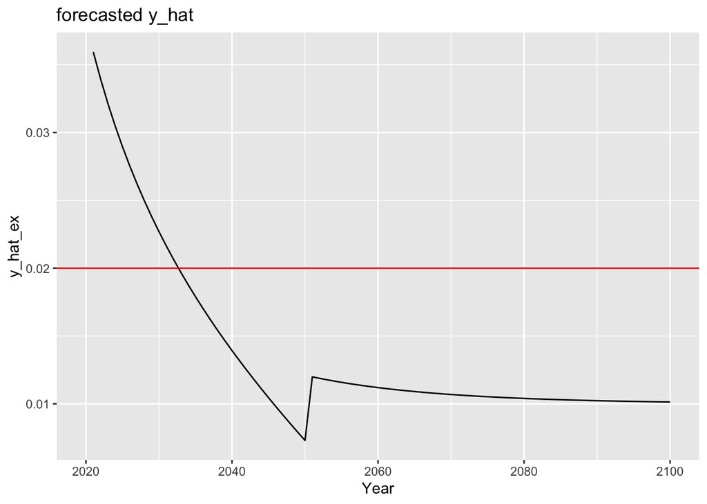

```r
ggplot(sim3_ex, mapping= aes(Year,y_hat_ex ))+
  geom_line()+
  geom_hline(yintercept = 0.020, color= "red")+
  labs(title= "forecasted y_hat")
```

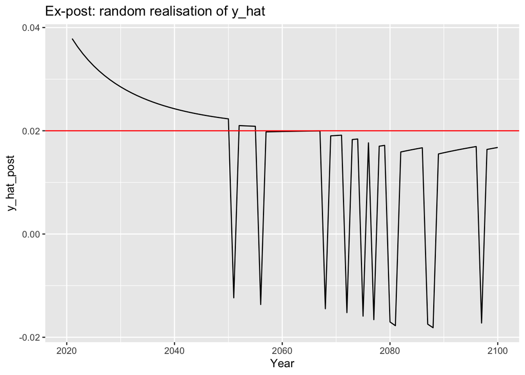

```r
# You can see that y_hat hits negative at times. but eventually it return to a bit below 0.02
ggplot(sim3_post, mapping= aes(Year,y_hat_post ))+
  geom_line()+
  geom_hline(yintercept = 0.020, color= "red")+
  labs(title= "Ex-post: random realisation of y_hat")
```

```r
table(w_sim3)
```

```
## w_sim3
##  0  1
## 70 11
```

## i) The big plot!! I will label the graph. I promise!

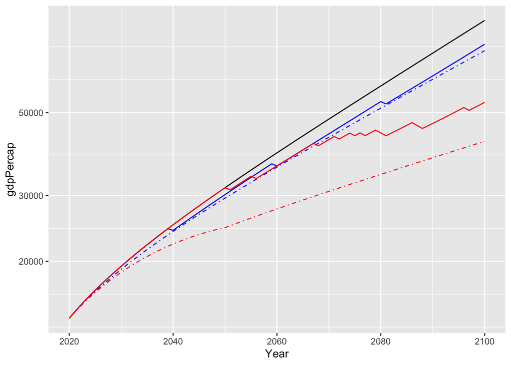

```r
ggplot()+

  #sim1 GDP per capita under simulation
  #Use a black line for simulation 1
  geom_line(sim_1, mapping= aes(x= Year, y=gdpPercap))+
  #the expected GDP per capita computed under simulations 2 and 3
  #dot-dashed lines for the expected GDP per capita;
  geom_line(sim2_ex, mapping= aes(x= Year, y=gdpPercap_ex), color="blue", linetype= "dotdash", alpha= 0.9)+
 geom_line(sim3_ex, mapping=  aes(x= Year, y=gdpPercap_ex), color="red", linetype= "dotdash", alpha= 0.9 )+
  #Random realisations plots
  geom_line(data= sim2_post, mapping= aes(x= Year, y=gdpPercap_post), color="blue", linetype= 1)+
  geom_line(data= sim3_post, mapping= aes(x= Year, y=gdpPercap_post), color="red")+
  expand_limits(y=0)+
  scale_y_log10()
```

So, this is all the code needed this far here. At least for R1. In God We Trust!